# Practical Machine Learning Course Project - Weight Lifting Exercise

Juan Carlos González Cardona

17 de septiembre de 2016

# Background

Using devices such as Jawbone Up, Nike FuelBand, and Fitbit it is now possible to collect a large amount of data about personal activity relatively inexpensively. These type of devices are part of the quantified self movement - a group of enthusiasts who take measurements about themselves regularly to improve their health, to find patterns in their behavior, or because they are tech geeks. One thing that people regularly do is quantify how much of a particular activity they do, but they rarely quantify how well they do it. In this project, your goal will be to use data from accelerometers on the belt, forearm, arm, and dumbell of 6 participants. They were asked to perform barbell lifts correctly and incorrectly in 5 different ways.

# Note

All code was putting in Appendix section for improve readability but the response of code was show. Excuse me for my poor english.

# Get data

Get data from repositories and define that separator, decimal and quote character, and NA strings for this case “NA”,“#DIV/0!”,“”.

# Preprocess

# Split data

Using Caret library to split training set into 2 sets (train 60% and valid 40%) to train models and valid accuracy.

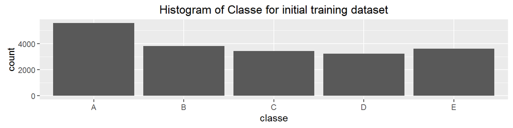

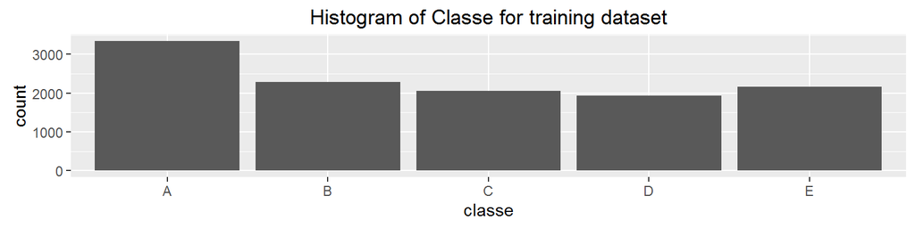

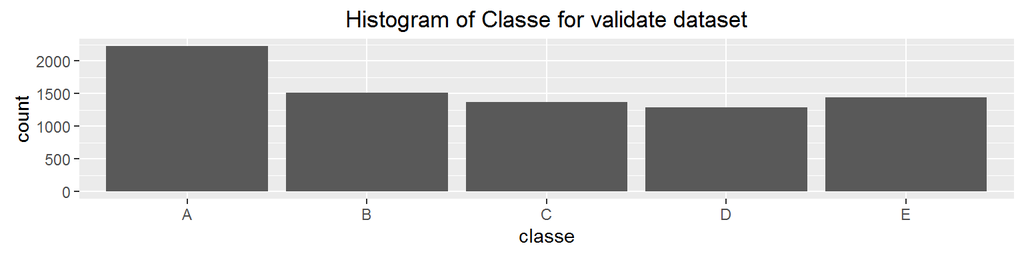

# Cross Validation

I using K-fold to cross validation to minimize variance. 10 folds take a lot of time for Random Forest and Gradient Boosting. To eval performance of each model i use Accuracy that is the proportion of correct classified observation within all observations, 1 minus accuracy is my expected out of sample error. To config this k-fold i used trainControl and method “cv”.

# Model Random Forest

```
## Confusion Matrix and Statistics
##
##           Reference
## Prediction    A    B    C    D    E
##          A 2230    5    0    0    0
##          B    2 1509   12    0    0
##          C    0    4 1356   35    1
##          D    0    0    0 1248    2
##          E    0    0    0    3 1439
##
## Overall Statistics
##
##                Accuracy : 0.9918
##                  95% CI : (0.9896, 0.9937)
##     No Information Rate : 0.2845
##     P-Value [Acc > NIR] : < 2.2e-16
##
##                   Kappa : 0.9897
##  Mcnemar's Test P-Value : NA
##
## Statistics by Class:
##
##                      Class: A Class: B Class: C Class: D Class: E
## Sensitivity            0.9991   0.9941   0.9912   0.9705   0.9979
## Specificity            0.9991   0.9978   0.9938   0.9997   0.9995
## Pos Pred Value         0.9978   0.9908   0.9713   0.9984   0.9979
## Neg Pred Value         0.9996   0.9986   0.9981   0.9942   0.9995
## Prevalence             0.2845   0.1935   0.1744   0.1639   0.1838
## Detection Rate         0.2842   0.1923   0.1728   0.1591   0.1834
## Detection Prevalence   0.2849   0.1941   0.1779   0.1593   0.1838
## Balanced Accuracy      0.9991   0.9959   0.9925   0.9851   0.9987
```

# Model Support Vector Machine

Fit to model using Support Vector Machine with default parameters. Accuracy was calculated using confusionMatrix and for this model was 78.1% (95% CI : [0.7717, 0.7901]).

```
## Confusion Matrix and Statistics
##
##           Reference
## Prediction    A    B    C    D    E
##          A 2064  198  120   94   76
##          B   40 1068  122   47  194
##          C   48  107 1047  147   88
##          D   70   26   35  939   74
##          E   10  119   44   59 1010
##
## Overall Statistics
##
##                Accuracy : 0.781
##                  95% CI : (0.7717, 0.7901)
##     No Information Rate : 0.2845
##     P-Value [Acc > NIR] : < 2.2e-16
##
##                   Kappa : 0.7215
##  Mcnemar's Test P-Value : < 2.2e-16
##
## Statistics by Class:
##
##                      Class: A Class: B Class: C Class: D Class: E
## Sensitivity            0.9247   0.7036   0.7654   0.7302   0.7004
## Specificity            0.9131   0.9363   0.9398   0.9688   0.9638
## Pos Pred Value         0.8088   0.7260   0.7286   0.8208   0.8132
## Neg Pred Value         0.9683   0.9294   0.9499   0.9482   0.9346
## Prevalence             0.2845   0.1935   0.1744   0.1639   0.1838
## Detection Rate         0.2631   0.1361   0.1334   0.1197   0.1287
## Detection Prevalence   0.3253   0.1875   0.1832   0.1458   0.1583
## Balanced Accuracy      0.9189   0.8199   0.8526   0.8495   0.8321
```

# Model Stochastic Gradient Boosting

```
## Confusion Matrix and Statistics
##
##           Reference
## Prediction    A    B    C    D    E
##          A 2196   55    0    1    4
##          B   25 1426   47    5   15
##          C    9   36 1306   57   11
##          D    2    1   13 1214   16
##          E    0    0    2    9 1396
##
## Overall Statistics
##
##                Accuracy : 0.9607
##                  95% CI : (0.9562, 0.9649)
##     No Information Rate : 0.2845
##     P-Value [Acc > NIR] : < 2.2e-16
##
##                   Kappa : 0.9503
##  Mcnemar's Test P-Value : 6.135e-13
##
## Statistics by Class:
##
##                      Class: A Class: B Class: C Class: D Class: E
## Sensitivity            0.9839   0.9394   0.9547   0.9440   0.9681
## Specificity            0.9893   0.9855   0.9826   0.9951   0.9983
## Pos Pred Value         0.9734   0.9394   0.9204   0.9743   0.9922
## Neg Pred Value         0.9936   0.9855   0.9904   0.9891   0.9929
## Prevalence             0.2845   0.1935   0.1744   0.1639   0.1838
## Detection Rate         0.2799   0.1817   0.1665   0.1547   0.1779
## Detection Prevalence   0.2875   0.1935   0.1809   0.1588   0.1793
## Balanced Accuracy      0.9866   0.9624   0.9686   0.9696   0.9832
```

# Decision

The best accuracy was for Random Forest (99.17%), was good for Stochastic Gradient Boosting (96.1%) and disapoint to Support Vector Machine (78.1%).

# Testing

Testing data set was evaluated with Random Forest model and was 100% accuracy when i answered the quiz in Coursera.

```
##  [1] B A B A A E D B A A B C B A E E A B B B
## Levels: A B C D E
```

# References

Velloso, E.; Bulling, A.; Gellersen, H.; Ugulino, W.; Fuks, H. Qualitative Activity Recognition of Weight Lifting Exercises. Proceedings of 4th International Conference in Cooperation with SIGCHI (Augmented Human ’13) . Stuttgart, Germany: ACM SIGCHI, 2013. http://groupware.les.inf.puc-rio.br/har#ixzz4KeETELOZ

# Appendix

## R code to Get Data

```r
urlTraining   <- "https://d396qusza40orc.cloudfront.net/predmachlearn/pml-training.csv"
urlTesting    <- "https://d396qusza40orc.cloudfront.net/predmachlearn/pml-testing.csv"

wd <- "C:\\Users\\juanc\\Dropbox\\DataScience\\Practical Machine Learning\\Project\\JHU-PracticalMachineLearning"
filesDirectory<- "data"
fileTraining  <- "data\\pml-training.csv"
fileTesting   <- "data\\pml-testing.csv"
setwd(wd)
#rm(list=ls())

if (!file.exists(filesDirectory)) {
  dir.create(filesDirectory)
 }

getData <- function(variableName, url, filename, ...){
  if(!exists(variableName)){
    if (!file.exists(filename)) {
      download.file(url, filename)
    }
    read.csv2(filename, ...)
  }
}

training <- getData("training", urlTraining, fileTraining, sep = ",", dec=".", quote = "\"", na.strings = c("NA","#DIV/0!",""))
testing <- getData("testing", urlTesting, fileTesting, sep = ",", dec=".", quote = "\"", na.strings = c("NA","#DIV/0!",""))
```

## R code to Preprocess

```r
training  <- training[,-c(1:7)]
testing   <- testing[,-c(1:7)]

colNACount    <- colSums(is.na(training))
colNoNACount  <- colSums(!is.na(training))

training <- training[, (colNACount / (colNoNACount + colNoNACount)) < 0.10 ]
testing <- testing[, (colNACount / (colNoNACount + colNoNACount)) < 0.10 ]
```

## R code to Split data

```r
library(caret)
set.seed(2804)
inTrain <- createDataPartition(training$classe, p = 0.6, list = FALSE)
train <- training[inTrain, ]
valid <- training[-inTrain, ]
```

```r
library(ggplot2)
qplot(classe, data = training, main = "Histogram of Classe for initial training dataset")
qplot(classe, data = train, main = "Histogram of Classe for training dataset")
qplot(classe, data = valid, main = "Histogram of Classe for validate dataset")
```

## R code to Cross Validation

```r
trControl <- trainControl(method = "cv", number = 10)
```

## R code to Model Random Forest

```r
modRF <- train(classe ~ ., data = train, method = "rf", trControl = trControl)
predRF <- predict(modRF, valid)

confusionMatrix(predRF, valid$classe)
```

## R code to Model Support Vector Machine

```r
modSVM <- train(classe ~ ., data = train, method = "svmLinear", trControl = trControl)
predSVM <- predict(modSVM, valid)
confusionMatrix(predSVM, valid$classe)
```

## R code to Model Stochastic Gradient Boosting

```r
modGBM <- train(classe ~ ., data = train, method = "gbm", trControl = trControl, verbose = FALSE)
predGBM <- predict(modGBM, valid)
confusionMatrix(predGBM, valid$classe)
```

## R code to Testing

```r
print(predict(modRF, newdata=testing))
```